# STAT/MATH 495: Problem Set 04

Tim Lee

2017-10-03

# Collaboration

Please indicate who you collaborated with on this assignment: Pei Gong, Vickie Ip, Leonard Yoon

# Load packages, data, model formulas

The credit data can be found on the following website: “http://www-bcf.usc.edu/~gareth/ISL/Credit.csv”. The CSV file was imported into RStudio and trained on multiple different model sizes.

I trained the following 7 models on `credit_train`…

```r
model1_formula <- as.formula("Balance ~ 1")
model2_formula <- as.formula("Balance ~ Income")
model3_formula <- as.formula("Balance ~ Income + Limit")
model4_formula <- as.formula("Balance ~ Income + Limit + Rating")
model5_formula <- as.formula("Balance ~ Income + Limit + Rating + Age")
model6_formula <- as.formula("Balance ~ Income + Limit + Rating + Age + Cards")
model7_formula <- as.formula("Balance ~ Income + Limit + Rating + Age + Cards + Education")
```

… where `credit_train` is defined below, along with `credit_test`.

The data are then divided into a training set of size 20 and a test set of size 380.

```r
set.seed(79)
credit_train <- credit %>%
  sample_n(20)
credit_test <- credit %>%
  anti_join(credit_train, by="ID")
```

# RMSE vs number of coefficients

### Calculating the RMSE for all Models

```r
# Placeholder vectors of length 7. For now, I've filled them with arbitrary
# values.
RMSE_train <- runif(n=7)
RMSE_test <- runif(n=7)

# RMSE for each value
for(i in 1:7){
  model_lm <- lm(get(paste0("model", i, "_formula")), data = credit_train)
  y_hat_test <- predict(model_lm, newdata = credit_test)
  y_hat_train <- predict(model_lm, newdata = credit_train)

  error_test <- credit_test[["Balance"]] - y_hat_test
  rmse_test <- sqrt(mean(error_test^2))

  error_train <- credit_train[["Balance"]] - y_hat_train
  rmse_train <- sqrt(mean(error_train^2))


  RMSE_test[i] <- rmse_test
  RMSE_train[i] <- rmse_train
}
```

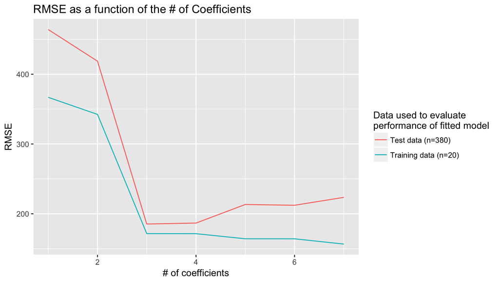

## Interpret the graph

Compare and contrast the two curves and hypothesize as to the root cause of any differences.

### Similarities

- Difference in RMSE from 2 to 3 coefficients: The curves both show dramatic increases in out-of-sample validity when the number of coefficients goes from 2 to 3. This occurs because the amount of information in the third variable of `Limit` is important for making predictions. That variable explains more of the variation in the data points than other variables.

### Differences

- As the number of coefficients increases past 3, the difference between the test data and the training data RMSE gets wider. The root cause of this is the fact that the training data is so small that it has less ability to separate the signal from the noise in the model. Thus, when there are more predictors, it is more difficult to partition given that there are only 20 observations to make out-of-sample predictios in the test set. For the training data, it can make better predictions on itself because it is not out-of-sample, which isn’t truly evaluating the effectiveness of a model. With 20 values in the training data, its RMSE goes down because it is becoming idiosyncratic to the model but it isn’t actually representative of the ability to predict data outside the sample.
- RMSE differences between test and training data: The test data generally has higher RMSE than the training data. The root cause of this is the fact that the training data only has 20 entries. It may not have enough power to produce a signal that is strong enough to capture the true model. Thus, the model from the training data produces an RMSE that is good for itself, but it cannot make some predictions for the test data. We can see the general area of where we’re overfitting!

# Bonus

Repeat the whole process, but let `credit_train` be a random sample of size 380 from `credit` instead of 20. Now compare and contrast this graph with the one above and hypothesize as to the root cause of any differences.

```r
credit_train <- credit %>%
  sample_n(380)
credit_test <- credit %>%
  anti_join(credit_train, by="ID")
```

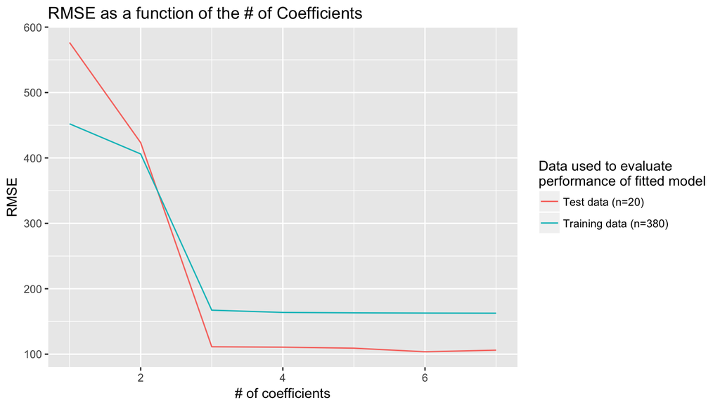

## Comparing the Graphs

For ease of comparison, the graphs have been reprinted next to each other. Furthermore, the axes have been changed to reflect the same maximum and minimum limits for the axes.

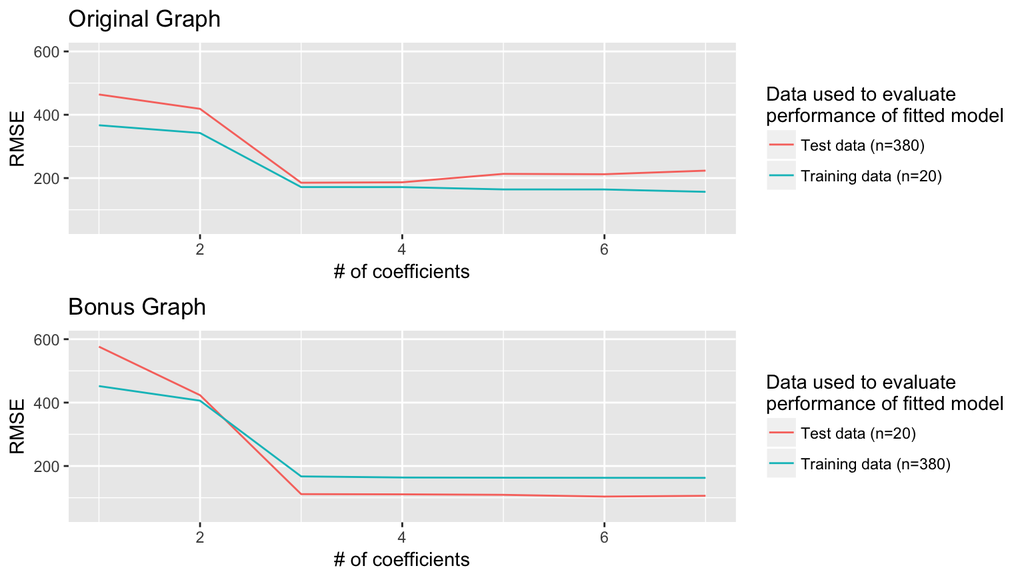

### Differences

- The amount of starting variation is influenced by the starting RMSE. However, the root cause of this is just the initial seed that is set. There is very little information when there is only one coefficient, where differences could be due to the random sample.
- After 3 coefficients, the original and bonus graph differ in the amount of divergence between the test and training data in RMSE. The original graph has the difference getting bigger, while the bonus graph has the difference leveling out. This is due to overfitting. With 20 data points in the training data of the original graph, adding more coefficients quickly leads to overfitting. However, with the 380 data points in the training data of the bonus graph, the model takes longer to overfit.